# Boqian_Mao_Biostat_620_Hw2

Author

Boqian Mao

## Step 1

```r
library(dplyr)
library(readr)

ind <- read_csv("chs_individual.csv")
reg <- read_csv("chs_regional.csv")
reg_clean <- reg %>% distinct(townname, .keep_all = TRUE)

n_ind <- nrow(ind)
dat <- ind %>% left_join(reg_clean, by = "townname")

get_mode <- function(x) {
  x <- x[!is.na(x)]
  if (length(x) == 0) return(NA)
  ux <- unique(x)
  ux[which.max(tabulate(match(x, ux)))]
}

id_vars <- c("townname", "male", "hispanic")

num_cols_all <- names(dat)[sapply(dat, is.numeric)]
num_cols_all <- setdiff(num_cols_all, id_vars)

is_binary01 <- function(x) {
  ux <- unique(x[!is.na(x)])
  length(ux) > 0 && all(ux %in% c(0, 1))
}
binary_num_cols <- num_cols_all[sapply(dat[num_cols_all], is_binary01)]

num_cols <- setdiff(num_cols_all, binary_num_cols)

cat_cols <- names(dat)[!sapply(dat, is.numeric)]
cat_cols <- setdiff(cat_cols, id_vars)
cat_cols <- union(cat_cols, binary_num_cols)

global_mean <- sapply(dat[num_cols], function(x) mean(x, na.rm = TRUE))
global_mode <- sapply(dat[cat_cols], get_mode)

dat_imp <- dat %>%
  group_by(male, hispanic) %>%
  mutate(across(all_of(num_cols), ~{
    gm <- mean(.x, na.rm = TRUE)
    fill <- ifelse(is.nan(gm), global_mean[cur_column()], gm)
    ifelse(is.na(.x), fill, .x)
  })) %>%
  ungroup()

dat_imp <- dat_imp %>%
  group_by(male, hispanic) %>%
  mutate(across(all_of(cat_cols), ~{
    m <- get_mode(.x)
    fill <- ifelse(is.na(m), global_mode[cur_column()], m)
    ifelse(is.na(.x), fill, .x)
  })) %>%
  ungroup()

print(head(dat_imp))
```

```
# A tibble: 6 × 49
    sid townname   male race  hispanic agepft height weight   bmi asthma
  <dbl> <chr>     <dbl> <chr>    <dbl>  <dbl>  <dbl>  <dbl> <dbl>  <dbl>
1     1 Lancaster     1 W            0  10.2    123    54    16.2      0
2     2 Lancaster     1 W            0  10.5    145    77    16.6      0
3     6 Lancaster     0 B            0  10.1    145   143    30.9      0
4     7 Lancaster     0 O            0  10.7    156    72    13.4      0
5     8 Lancaster     0 W            1   9.78   132    61    15.9      0
6    10 Lancaster     1 O            1   9.97   139.   82.8  19.4      0
# ℹ 39 more variables: active_asthma <dbl>, father_asthma <dbl>,
#   mother_asthma <dbl>, wheeze <dbl>, hayfever <dbl>, allergy <dbl>,
#   educ_parent <dbl>, smoke <dbl>, pets <dbl>, gasstove <dbl>, fev <dbl>,
#   fvc <dbl>, mmef <dbl>, pm25_mass <dbl>, pm25_so4 <dbl>, pm25_no3 <dbl>,
#   pm25_nh4 <dbl>, pm25_oc <dbl>, pm25_ec <dbl>, pm25_om <dbl>, pm10_oc <dbl>,
#   pm10_ec <dbl>, pm10_tc <dbl>, formic <dbl>, acetic <dbl>, hcl <dbl>,
#   hno3 <dbl>, o3_max <dbl>, o3106 <dbl>, o3_24 <dbl>, no2 <dbl>, …
```

```r
nrow(ind)
```

```
[1] 1200
```

```r
nrow(dat_imp)
```

```
[1] 1200
```

## Step 2

```r
dat_imp <- dat_imp %>%
  mutate(
    obesity_level = case_when(
      bmi < 14 ~ "underweight",
      bmi >= 14 & bmi < 22 ~ "normal",
      bmi >= 22 & bmi <= 24 ~ "overweight",
      bmi > 24 ~ "obese",
    ),
    obesity_level = factor(obesity_level,
                           levels = c("underweight", "normal", "overweight", "obese"))
  )

print(head(dat_imp %>% select(bmi, obesity_level)))
```

```
# A tibble: 6 × 2
    bmi obesity_level
  <dbl> <fct>
1  16.2 normal
2  16.6 normal
3  30.9 obese
4  13.4 underweight
5  15.9 normal
6  19.4 normal
```

```r
# Summary table
obesity_summary <- dat_imp %>%
  group_by(obesity_level) %>%
  summarise(
    min_BMI = min(bmi),
    max_BMI = max(bmi),
    n = n(),
    .groups = "drop"
  )

print(obesity_summary)
```

```
# A tibble: 4 × 4
  obesity_level min_BMI max_BMI     n
  <fct>           <dbl>   <dbl> <int>
1 underweight      11.3    14.0    35
2 normal           14.0    22.0   975
3 overweight       22.0    24.0    87
4 obese            24.0    41.3   103
```

## Step 3

```r
dat_imp <- dat_imp %>%
  mutate(
    shs_bin = case_when(
      smoke %in% c(1) ~ 1,
      smoke %in% c(0) ~ 0,
      TRUE ~ NA_real_
    ),
    gas_bin = case_when(
      gasstove %in% c(1) ~ 1,
      gasstove %in% c(0) ~ 0,
      TRUE ~ NA_real_
      ),
    smoke_gas_exposure = case_when(
      shs_bin == 0 & gas_bin == 0 ~ "none",
      shs_bin == 1 & gas_bin == 0 ~ "second_hand_smoke_only",
      shs_bin == 0 & gas_bin == 1 ~ "gas_stove_only",
      shs_bin == 1 & gas_bin == 1 ~ "both",
      TRUE ~ NA_character_
    ),
    smoke_gas_exposure = factor(
      smoke_gas_exposure,
      levels = c("none", "second_hand_smoke_only", "gas_stove_only", "both")
    )
  )

print(head(dat_imp %>% select(smoke, gasstove, smoke_gas_exposure)))
```

```
# A tibble: 6 × 3
  smoke gasstove smoke_gas_exposure
  <dbl>    <dbl> <fct>
1     0        1 gas_stove_only
2     0        0 none
3     0        1 gas_stove_only
4     1        1 both
5     0        0 none
6     0        1 gas_stove_only
```

```r
table(dat_imp$smoke_gas_exposure)
```

```
                  none second_hand_smoke_only         gas_stove_only
                   219                     36                    791
                  both
                   154
```

## Step 4

```r
dat_imp <- dat_imp %>%
  mutate(sex = ifelse(male == 1, "male", "female"))
```

```r
tab_sex <- dat_imp %>%
  group_by(sex) %>%
  summarise(
    n = n(),
    mean_fev = mean(fev, na.rm = TRUE),
    sd_fev = sd(fev, na.rm = TRUE),
    .groups = "drop"
  )
print(tab_sex)
```

```
# A tibble: 2 × 4
  sex        n mean_fev sd_fev
  <chr>  <int>    <dbl>  <dbl>
1 female   610    1959.   312.
2 male     590    2104.   308.
```

```r
tab_town <- dat_imp %>%
  group_by(townname) %>%
  summarise(
    n = n(),
    mean_fev = mean(fev, na.rm = TRUE),
    sd_fev = sd(fev, na.rm = TRUE),
    .groups = "drop"
  ) %>%
  arrange(desc(mean_fev))
print(tab_town)
```

```
# A tibble: 12 × 4
   townname          n mean_fev sd_fev
   <chr>         <int>    <dbl>  <dbl>
 1 Alpine          100    2087.   291.
 2 Lake Gregory    100    2085.   320.
 3 Atascadero      100    2076.   324.
 4 Lake Elsinore   100    2039.   304.
 5 Lompoc          100    2034.   351.
 6 San Dimas       100    2027.   319.
 7 Santa Maria     100    2026.   312.
 8 Upland          100    2024.   343.
 9 Lancaster       100    2003.   317.
10 Riverside       100    1990.   278.
11 Long Beach      100    1986.   319.
12 Mira Loma       100    1985.   325.
```

```r
tab_obesity <- dat_imp %>%
  group_by(obesity_level) %>%
  summarise(
    n = n(),
    mean_fev = mean(fev, na.rm = TRUE),
    sd_fev = sd(fev, na.rm = TRUE),
    .groups = "drop"
  )
print(tab_obesity)
```

```
# A tibble: 4 × 4
  obesity_level     n mean_fev sd_fev
  <fct>         <int>    <dbl>  <dbl>
1 underweight      35    1698.   303.
2 normal          975    2000.   295.
3 overweight       87    2224.   317.
4 obese           103    2266.   325.
```

```r
tab_exposure <- dat_imp %>%
  group_by(smoke_gas_exposure) %>%
  summarise(
    n = n(),
    mean_fev = mean(fev, na.rm = TRUE),
    sd_fev = sd(fev, na.rm = TRUE),
    .groups = "drop"
  )
print(tab_exposure)
```

```
# A tibble: 4 × 4
  smoke_gas_exposure         n mean_fev sd_fev
  <fct>                  <int>    <dbl>  <dbl>
1 none                     219    2057.   329.
2 second_hand_smoke_only    36    2056.   296.
3 gas_stove_only           791    2023.   319.
4 both                     154    2025.   301.
```

## EDA

```r
library(ggplot2)

dim(dat_imp)
```

```
[1] 1200   54
```

```r
str(dat_imp)
```

```
tibble [1,200 × 54] (S3: tbl_df/tbl/data.frame)
 $ sid               : num [1:1200] 1 2 6 7 8 10 13 16 19 21 ...
 $ townname          : chr [1:1200] "Lancaster" "Lancaster" "Lancaster" "Lancaster" ...
 $ male              : num [1:1200] 1 1 0 0 0 1 1 0 0 0 ...
 $ race              : chr [1:1200] "W" "W" "B" "O" ...
 $ hispanic          : num [1:1200] 0 0 0 0 1 1 1 0 0 1 ...
 $ agepft            : num [1:1200] 10.15 10.46 10.1 10.75 9.78 ...
 $ height            : num [1:1200] 123 145 145 156 132 ...
 $ weight            : num [1:1200] 54 77 143 72 61 ...
 $ bmi               : num [1:1200] 16.2 16.6 30.9 13.4 15.9 ...
 $ asthma            : num [1:1200] 0 0 0 0 0 0 0 1 0 0 ...
 $ active_asthma     : num [1:1200] 0 0 0 0 0 1 0 0 0 0 ...
 $ father_asthma     : num [1:1200] 0 0 0 0 1 1 0 0 0 0 ...
 $ mother_asthma     : num [1:1200] 0 0 0 0 0 0 0 1 0 0 ...
 $ wheeze            : num [1:1200] 0 1 0 1 1 0 0 1 0 0 ...
```

[output cut: 40 more lines]

```r
head(dat_imp)
```

```
# A tibble: 6 × 54
    sid townname   male race  hispanic agepft height weight   bmi asthma
  <dbl> <chr>     <dbl> <chr>    <dbl>  <dbl>  <dbl>  <dbl> <dbl>  <dbl>
1     1 Lancaster     1 W            0  10.2    123    54    16.2      0
2     2 Lancaster     1 W            0  10.5    145    77    16.6      0
3     6 Lancaster     0 B            0  10.1    145   143    30.9      0
4     7 Lancaster     0 O            0  10.7    156    72    13.4      0
5     8 Lancaster     0 W            1   9.78   132    61    15.9      0
6    10 Lancaster     1 O            1   9.97   139.   82.8  19.4      0
# ℹ 44 more variables: active_asthma <dbl>, father_asthma <dbl>,
#   mother_asthma <dbl>, wheeze <dbl>, hayfever <dbl>, allergy <dbl>,
#   educ_parent <dbl>, smoke <dbl>, pets <dbl>, gasstove <dbl>, fev <dbl>,
#   fvc <dbl>, mmef <dbl>, pm25_mass <dbl>, pm25_so4 <dbl>, pm25_no3 <dbl>,
#   pm25_nh4 <dbl>, pm25_oc <dbl>, pm25_ec <dbl>, pm25_om <dbl>, pm10_oc <dbl>,
#   pm10_ec <dbl>, pm10_tc <dbl>, formic <dbl>, acetic <dbl>, hcl <dbl>,
#   hno3 <dbl>, o3_max <dbl>, o3106 <dbl>, o3_24 <dbl>, no2 <dbl>, …
```

```r
tail(dat_imp)
```

```
# A tibble: 6 × 54
    sid townname  male race  hispanic agepft height weight   bmi asthma
  <dbl> <chr>    <dbl> <chr>    <dbl>  <dbl>  <dbl>  <dbl> <dbl>  <dbl>
1  2046 Lompoc       0 O            1   9.47   142   106    23.9      0
2  2047 Lompoc       0 W            1   9.63   136    68    16.7      0
3  2048 Lompoc       0 O            1   9.47   133    68    17.5      0
4  2049 Lompoc       1 O            1   9.73   141   104    23.8      0
5  2050 Lompoc       0 O            1   9.88   145   119    25.7      0
6  2053 Upland       0 W            0   9.85   139.   77.4  18.1      0
# ℹ 44 more variables: active_asthma <dbl>, father_asthma <dbl>,
#   mother_asthma <dbl>, wheeze <dbl>, hayfever <dbl>, allergy <dbl>,
#   educ_parent <dbl>, smoke <dbl>, pets <dbl>, gasstove <dbl>, fev <dbl>,
#   fvc <dbl>, mmef <dbl>, pm25_mass <dbl>, pm25_so4 <dbl>, pm25_no3 <dbl>,
#   pm25_nh4 <dbl>, pm25_oc <dbl>, pm25_ec <dbl>, pm25_om <dbl>, pm10_oc <dbl>,
#   pm10_ec <dbl>, pm10_tc <dbl>, formic <dbl>, acetic <dbl>, hcl <dbl>,
#   hno3 <dbl>, o3_max <dbl>, o3106 <dbl>, o3_24 <dbl>, no2 <dbl>, …
```

```r
dat_imp %>%
  summarise(
    n = n(),
    na_BMI = sum(is.na(bmi)),
    na_fev = sum(is.na(fev)),
    na_pm25 = sum(is.na(pm25_mass)),
    na_smoke_gas = sum(is.na(smoke_gas_exposure)),
    na_obesity = sum(is.na(obesity_level))
  )
```

```
# A tibble: 1 × 6
      n na_BMI na_fev na_pm25 na_smoke_gas na_obesity
  <int>  <int>  <int>   <int>        <int>      <int>
1  1200      0      0       0            0          0
```

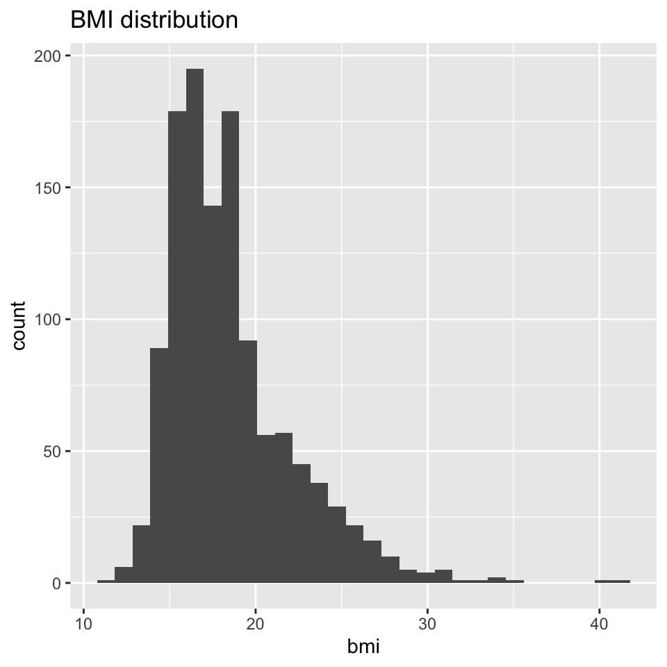

```r
ggplot(dat_imp, aes(x = bmi)) + geom_histogram(bins = 30) + labs(title="BMI distribution")
```

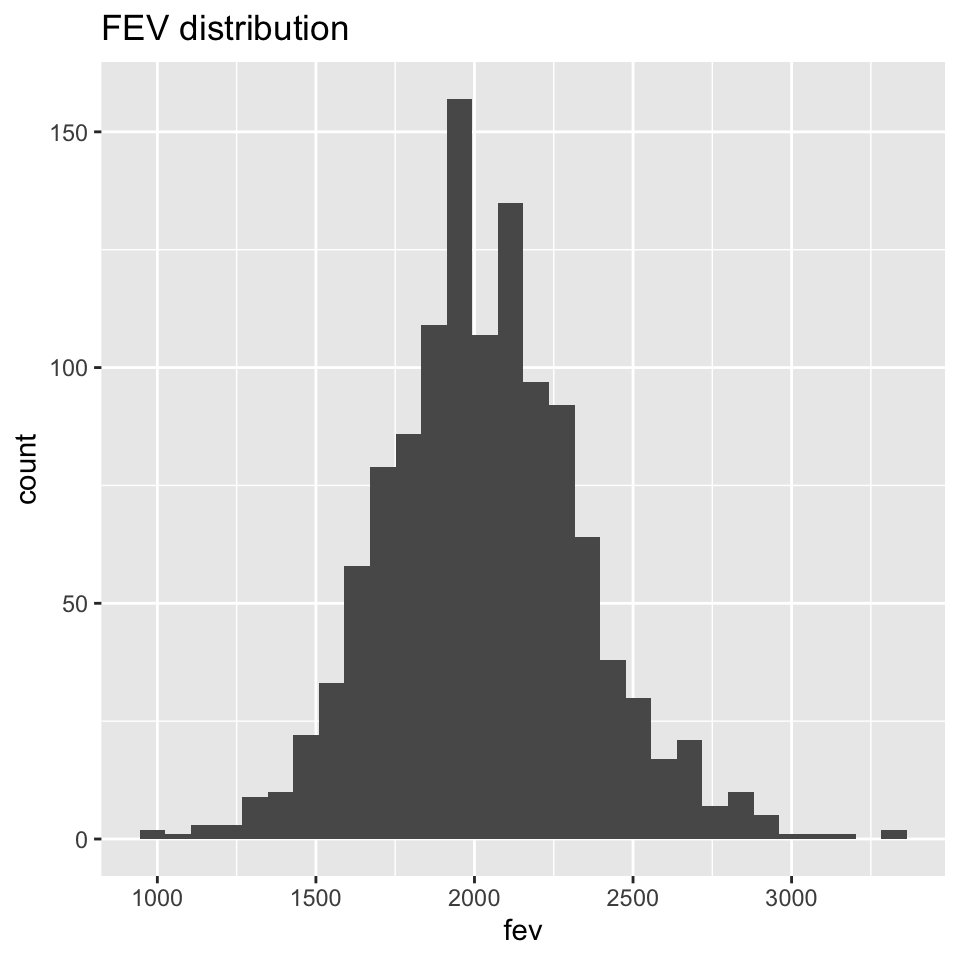

```r
ggplot(dat_imp, aes(x = fev)) + geom_histogram(bins = 30) + labs(title="FEV distribution")
```

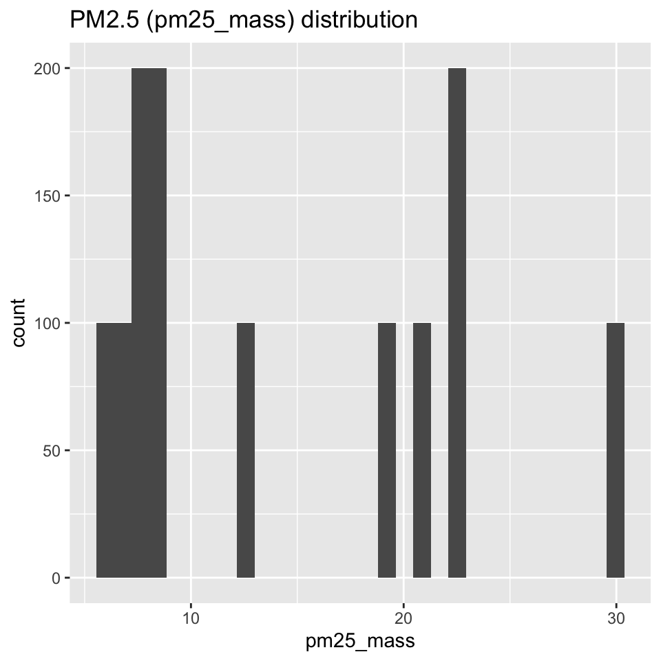

```r
ggplot(dat_imp, aes(x = pm25_mass)) + geom_histogram(bins = 30) + labs(title="PM2.5 (pm25_mass) distribution")
```

BMI is right-skewed with a small number of high-BMI observations, FEV appears closed to normal, and pm25_mass shows a discrete pattern . These patterns inform how we interpret associations with FEV in subsequent analyses.

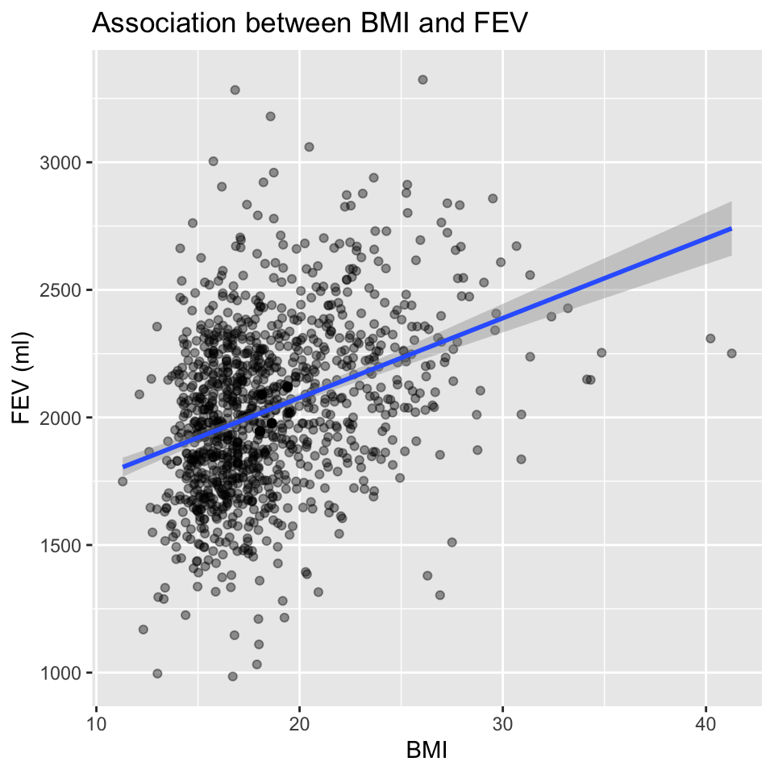

```r
# BMI & FEV
ggplot(dat_imp, aes(x = bmi, y = fev)) +
  geom_point(alpha = 0.4) +
  geom_smooth(method = "lm", se = TRUE) +
  labs(title = "Association between BMI and FEV", x="BMI", y="FEV (ml)")
```

```r
cor(dat_imp$bmi, dat_imp$fev, use = "complete.obs")
```

```
[1] 0.357112
```

```r
m1 <- lm(fev ~ bmi, data = dat_imp)
summary(m1)
```

```
Call:
lm(formula = fev ~ bmi, data = dat_imp)

Residuals:
    Min      1Q  Median      3Q     Max
-989.47 -193.88  -11.32  179.43 1305.46

Coefficients:
            Estimate Std. Error t value Pr(>|t|)
(Intercept)  1452.46      44.49   32.65   <2e-16 ***
bmi            31.23       2.36   13.23   <2e-16 ***
---
Signif. codes:  0 '***' 0.001 '**' 0.01 '*' 0.05 '.' 0.1 ' ' 1

Residual standard error: 297.2 on 1198 degrees of freedom
Multiple R-squared:  0.1275,    Adjusted R-squared:  0.1268
F-statistic: 175.1 on 1 and 1198 DF,  p-value: < 2.2e-16
```

The plot shows a clear positive association between BMI and FEV. As BMI increases, FEV tends to increase on average. However, the points are widely scattered, especially in the main BMI range. It’s suggesting BMI explains only part of the variability in FEV and other factors likely contribute as well.

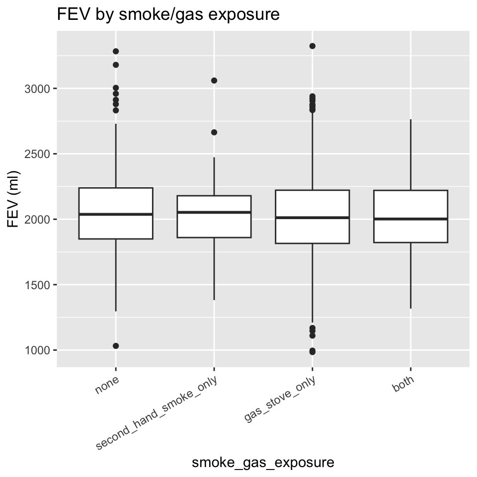

```r
# Smoke gas & FEV
ggplot(dat_imp, aes(x = smoke_gas_exposure, y = fev)) +
  geom_boxplot() +
  labs(title="FEV by smoke/gas exposure", x="smoke_gas_exposure", y="FEV (ml)") +
  theme(axis.text.x = element_text(angle = 30, hjust = 1))
```

```r
m2 <- lm(fev ~ smoke_gas_exposure, data = dat_imp)
summary(m2)
```

```
Call:
lm(formula = fev ~ smoke_gas_exposure, data = dat_imp)

Residuals:
    Min      1Q  Median      3Q     Max
-1037.8  -205.3   -12.0   190.7  1301.0

Coefficients:
                                          Estimate Std. Error t value Pr(>|t|)
(Intercept)                              2056.6934    21.4950  95.682   <2e-16
smoke_gas_exposuresecond_hand_smoke_only   -0.9794    57.2079  -0.017    0.986
smoke_gas_exposuregas_stove_only          -34.0226    24.2890  -1.401    0.162
smoke_gas_exposureboth                    -31.9152    33.4527  -0.954    0.340

(Intercept)                              ***
smoke_gas_exposuresecond_hand_smoke_only
smoke_gas_exposuregas_stove_only
smoke_gas_exposureboth
---
Signif. codes:  0 '***' 0.001 '**' 0.01 '*' 0.05 '.' 0.1 ' ' 1

Residual standard error: 318.1 on 1196 degrees of freedom
Multiple R-squared:  0.001868,  Adjusted R-squared:  -0.0006354
F-statistic: 0.7462 on 3 and 1196 DF,  p-value: 0.5246
```

Across the four smoke & gas exposure groups, the medians and interquartile ranges are quite similar, indicating only small differences in FEV by exposure category. Some groups show more outliers, but overall the distributions overlap substantially.

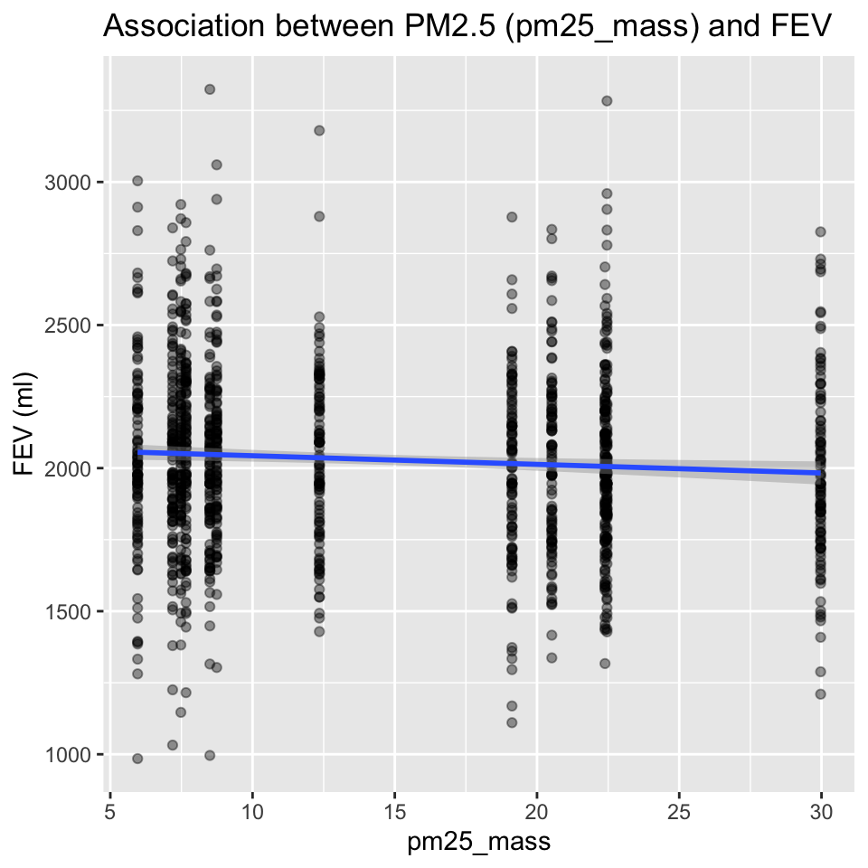

```r
## PM2.5 & FEV
ggplot(dat_imp, aes(x = pm25_mass, y = fev)) +
  geom_point(alpha = 0.4) +
  geom_smooth(method = "lm", se = TRUE) +
  labs(title="Association between PM2.5 (pm25_mass) and FEV", x="pm25_mass", y="FEV (ml)")
```

```r
cor(dat_imp$pm25_mass, dat_imp$fev, use = "complete.obs")
```

```
[1] -0.07341317
```

```r
m3 <- lm(fev ~ pm25_mass, data = dat_imp)
summary(m3)
```

```
Call:
lm(formula = fev ~ pm25_mass, data = dat_imp)

Residuals:
     Min       1Q   Median       3Q      Max
-1070.63  -206.57   -13.33   195.87  1277.65

Coefficients:
            Estimate Std. Error t value Pr(>|t|)
(Intercept) 2073.452     19.309 107.383   <2e-16 ***
pm25_mass     -3.016      1.184  -2.548    0.011 *
---
Signif. codes:  0 '***' 0.001 '**' 0.01 '*' 0.05 '.' 0.1 ' ' 1

Residual standard error: 317.3 on 1198 degrees of freedom
Multiple R-squared:  0.005389,  Adjusted R-squared:  0.004559
F-statistic: 6.492 on 1 and 1198 DF,  p-value: 0.01096
```

PM2.5 values appear in vertical bands, consistent with a community-level exposure assigned to many individuals. The fitted line shows a slight negative trend, implying higher PM2.5 is associated with marginally lower FEV, but the relationship looks weak given the large spread of FEV at each exposure level.

```r
m4 <- lm(fev ~ bmi + pm25_mass + smoke_gas_exposure + sex + obesity_level, data = dat_imp)
summary(m4)
```

```
Call:
lm(formula = fev ~ bmi + pm25_mass + smoke_gas_exposure + sex +
    obesity_level, data = dat_imp)

Residuals:
   Min     1Q Median     3Q    Max
-970.1 -190.7  -10.0  168.9 1215.2

Coefficients:
                                         Estimate Std. Error t value Pr(>|t|)
(Intercept)                              1358.510     78.107  17.393  < 2e-16
bmi                                        27.451      4.249   6.460 1.52e-10
pm25_mass                                  -2.310      1.079  -2.140  0.03258
smoke_gas_exposuresecond_hand_smoke_only  -29.558     51.858  -0.570  0.56880
smoke_gas_exposuregas_stove_only          -38.939     22.051  -1.766  0.07768
smoke_gas_exposureboth                    -63.427     30.435  -2.084  0.03737
sexmale                                   130.777     16.702   7.830 1.07e-14
obesity_levelnormal                       168.842     52.529   3.214  0.00134
obesity_leveloverweight                   228.273     70.749   3.227  0.00129
obesity_levelobese                        158.529     80.967   1.958  0.05047

(Intercept)                              ***
bmi                                      ***
pm25_mass                                *
smoke_gas_exposuresecond_hand_smoke_only
smoke_gas_exposuregas_stove_only         .
smoke_gas_exposureboth                   *
sexmale                                  ***
obesity_levelnormal                      **
obesity_leveloverweight                  **
obesity_levelobese                       .
---
Signif. codes:  0 '***' 0.001 '**' 0.01 '*' 0.05 '.' 0.1 ' ' 1

Residual standard error: 287.7 on 1190 degrees of freedom
Multiple R-squared:  0.1876,    Adjusted R-squared:  0.1815
F-statistic: 30.53 on 9 and 1190 DF,  p-value: < 2.2e-16
```

I added all related variables to the model. BMI is positively associated with FEV. PM2.5 shows a small but statistically significant negative association with FEV. Using none as the reference category for smoke & gas exposure, the both exposure group has significantly lower FEV. The gas_stove_only group is also lower but only marginally significant, while second_hand_smoke_only is not significantly different from the reference. Sex is strongly associated with FEV. Compared to the underweight reference group, the normal and overweight obesity categories have significantly higher FEV, while the obese category is borderline.

## Visualization

```r
library(dplyr)
library(ggplot2)
library(viridis)
library(RColorBrewer)
library(leaflet)
```

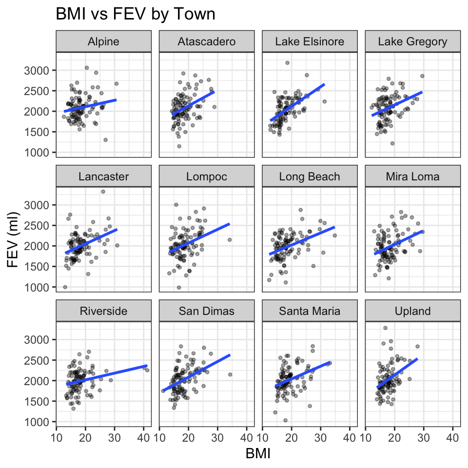

```r
## 1
p1 <- ggplot(dat_imp, aes(x = bmi, y = fev)) +
  geom_point(alpha = 0.35, size = 0.9) +
  geom_smooth(method = "lm", se = FALSE) +
  facet_wrap(~ townname) +
  labs(
    title = "BMI vs FEV by Town",
    x = "BMI",
    y = "FEV (ml)"
  ) +
  theme_bw()

print(p1)
```

Across all 12 towns, the fitted regression lines are generally positive, indicating that higher BMI is associated with higher FEV within each community. The vertical spread of points differs across towns, suggesting that town-level factors may influence overall FEV levels and contribute to heterogeneity in the BMI–FEV relationship.

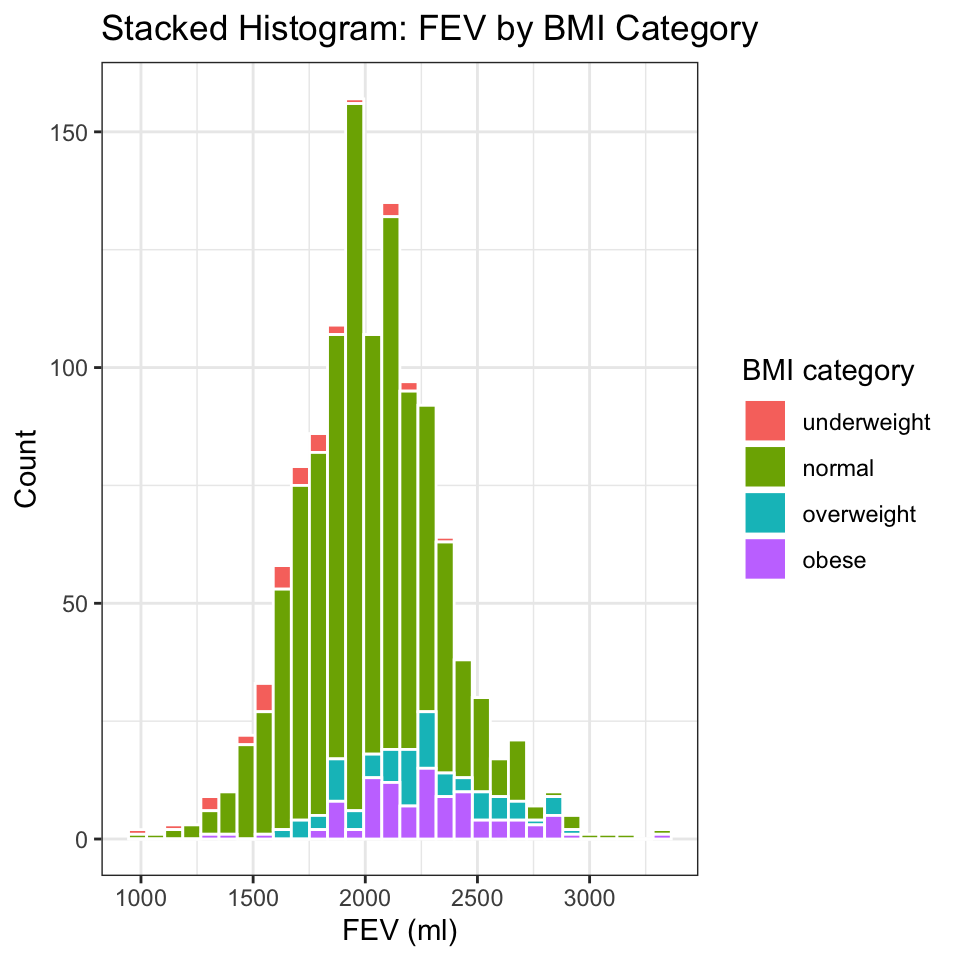

```r
## 2
p2a <- ggplot(dat_imp, aes(x = fev, fill = obesity_level)) +
  geom_histogram(bins = 30, position = "stack", color = "white") +
  labs(
    title = "Stacked Histogram: FEV by BMI Category",
    x = "FEV (ml)",
    y = "Count",
    fill = "BMI category"
  ) +
  theme_bw()

p2b <- ggplot(dat_imp, aes(x = fev, fill = smoke_gas_exposure)) +
  geom_histogram(bins = 30, position = "stack", color = "white") +
  labs(
    title = "Stacked Histogram: FEV by Smoke/Gas Exposure",
    x = "FEV (ml)",
    y = "Count",
    fill = "Exposure"
  ) +
  theme_bw()

print(p2a)
```

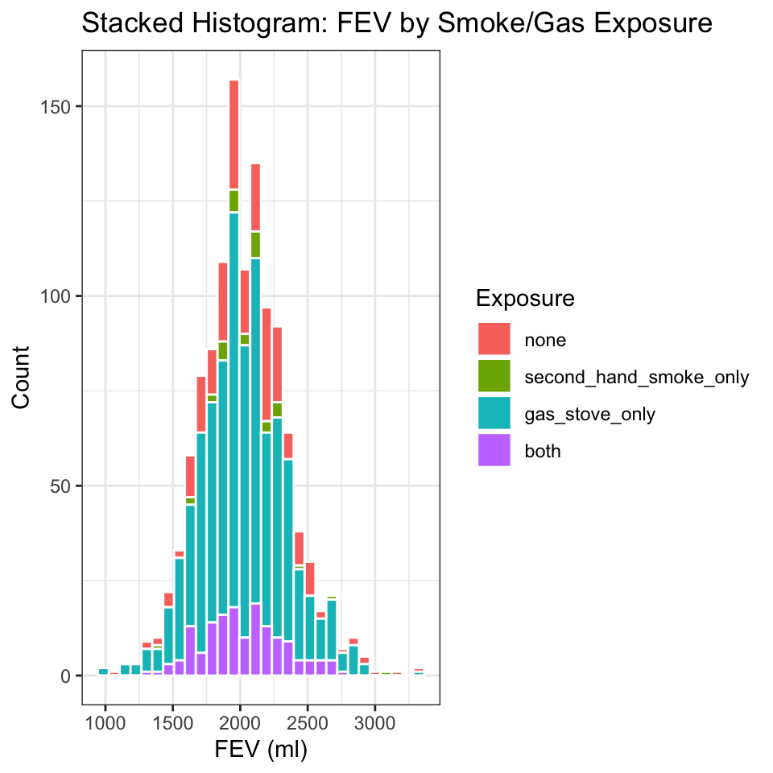

```r
print(p2b)
```

The histogram shows that most observations fall in the normal BMI category, which contributes the largest share of counts across nearly all FEV bins. As FEV increases, the contribution from the overweight and obese categories becomes more visible, suggesting that higher BMI categories may be associated with slightly higher FEV on average. However, the distributions still overlap substantially, so BMI category alone does not fully separate FEV levels.

The overall FEV distribution appears broadly similar across exposure categories, with most values concentrated around ~1700–2400 ml. The gas_stove_only group dominates the counts in most bins, indicating it is the most common exposure category in the sample. Because the colored distributions overlap heavily, any differences in FEV by exposure category look subtle in this stacked view.

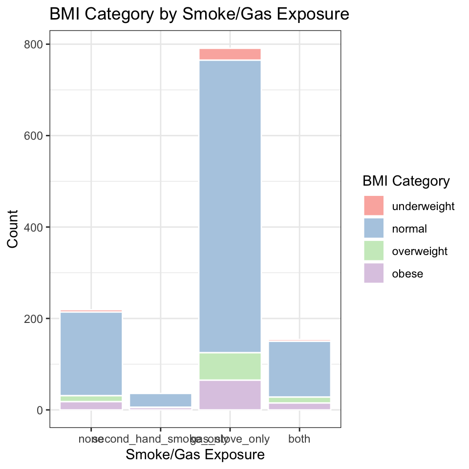

```r
p3_count <- ggplot(dat_imp, aes(x = smoke_gas_exposure, fill = obesity_level)) +
  geom_bar(position = "stack", color = "white") +
  scale_fill_brewer(palette = "Pastel1") +
  labs(
    title = "BMI Category by Smoke/Gas Exposure",
    x = "Smoke/Gas Exposure",
    y = "Count",
    fill = "BMI Category"
  ) +
  theme_bw()

p3_prop <- ggplot(dat_imp, aes(x = smoke_gas_exposure, fill = obesity_level)) +
  geom_bar(position = "fill", color = "white") +
  scale_fill_brewer(palette = "Pastel1") +
  scale_y_continuous(labels = scales::percent_format()) +
  labs(
    title = "Proportion of BMI Category by Smoke/Gas Exposure",
    x = "Smoke/Gas Exposure",
    y = "Proportion",
    fill = "BMI Category"
  ) +
  theme_bw()


print(p3_count)
```

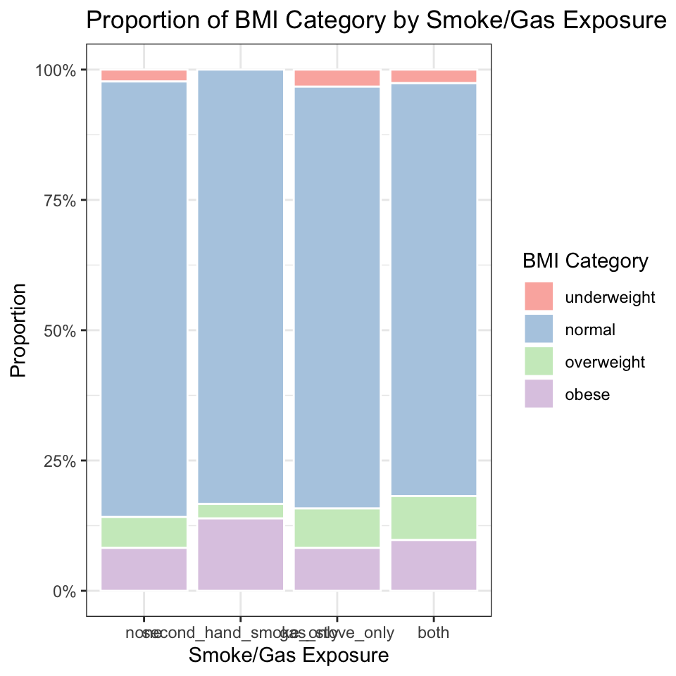

```r
print(p3_prop)
```

BMI Category by Smoke/Gas Exposure bar chart shows the number of children in each BMI category within each smoke/gas exposure group. The gas_only group contains the largest number of observations overall, and across all exposure groups the normal BMI category is the most common. The overweight and obese categories are present in every exposure group but make up a smaller share of the total counts.

Proportion of BMI Category by Smoke/Gas Exposure bar chart compares the composition of BMI categories across exposure groups while accounting for different sample sizes. The normal BMI category dominates in every exposure group, but the both group appears to have a slightly larger proportion of overweight/obese individuals compared with the neither group.

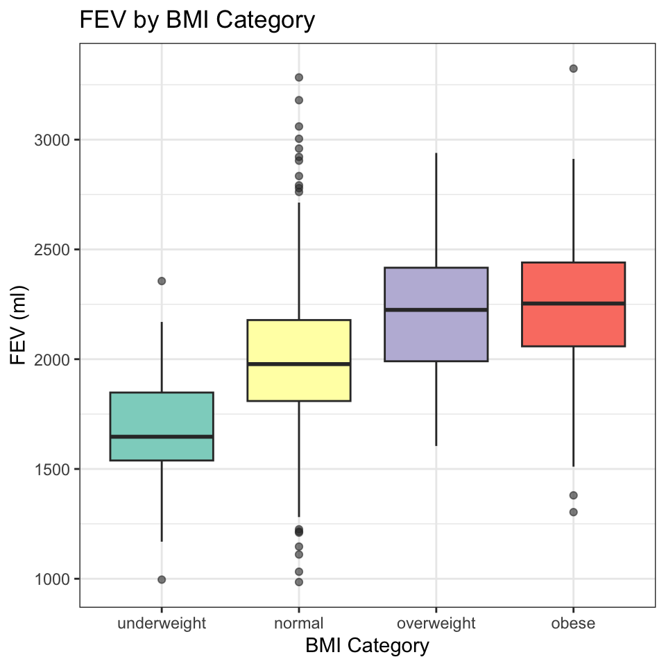

```r
## 4
p4_bmi <- ggplot(dat_imp, aes(x = obesity_level, y = fev, fill = obesity_level)) +
  geom_boxplot(outlier.alpha = 0.6) +
  scale_fill_brewer(palette = "Set3", guide = "none") +
  labs(
    title = "FEV by BMI Category",
    x = "BMI Category",
    y = "FEV (ml)"
  ) +
  theme_bw()

p4_exp <- ggplot(dat_imp, aes(x = smoke_gas_exposure, y = fev, fill = smoke_gas_exposure)) +
  geom_boxplot(outlier.alpha = 0.6) +
  scale_fill_brewer(palette = "Set3", guide = "none") +
  labs(
    title = "FEV by Smoke/Gas Exposure",
    x = "Smoke/Gas Exposure",
    y = "FEV (ml)"
  ) +
  theme_bw()

print(p4_bmi)
```

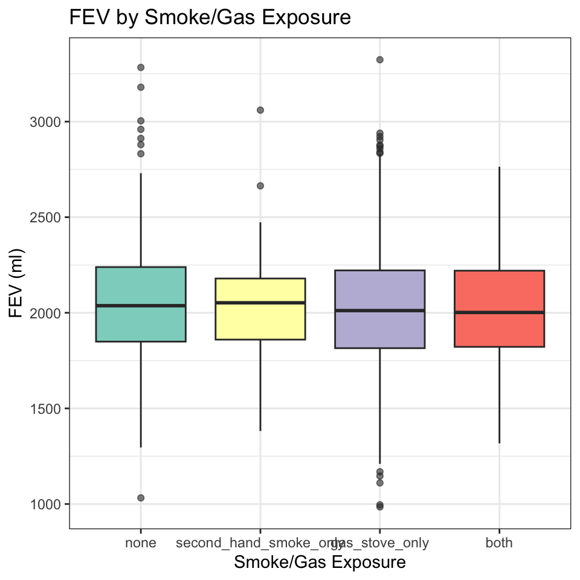

```r
print(p4_exp)
```

FEV by BMI Category Boxplot shows that FEV tends to increase across BMI categories, with the underweight group showing the lowest median FEV and the overweight/obese groups showing higher medians. This pattern suggests a positive association between BMI category and lung function.

FEV by Smoke/Gas Exposure Boxplot shows the distributions of FEV across smoke/gas exposure categories are highly overlapping. The gas_only and both groups appear to have slightly lower medians than the neither group, but the difference is small relative to within-group variability. This suggests that smoke and gas exposure may have a weak or subtle association with FEV in the raw data and may be clearer after adjusting for other factors.

```r
## 5
town_pm <- dat_imp %>%
  group_by(townname) %>%
  summarise(
    pm25 = mean(pm25_mass, na.rm = TRUE),
    .groups = "drop"
  )

town_geo <- dat_imp %>%
  group_by(townname) %>%
  summarise(
    pm25 = mean(pm25_mass, na.rm = TRUE),
    lat = first(lat),
    lon = first(lon),
    .groups = "drop"
  )

pal <- colorNumeric(palette = "YlOrRd", domain = town_geo$pm25)

leaflet(town_geo) %>%
  addProviderTiles(providers$CartoDB.Positron) %>%
  addCircleMarkers(
    lng = ~lon, lat = ~lat,
    radius = 6,
    color = ~pal(pm25),
    stroke = TRUE, weight = 1,
    fillOpacity = 0.85,
    popup = ~paste0("<b>", townname, "</b><br>PM2.5: ", round(pm25, 2))
  ) %>%
  addLegend("bottomright", pal = pal, values = ~pm25,
            title = "PM2.5 (pm25_mass)")
```

[interactive chart not shown]

Leaflet map shows clear spatial variation in PM2.5 concentrations across the CHS towns. The highest PM2.5 values cluster in the inland Southern California and San Bernardino–Riverside area, while lower PM2.5 levels appear more often in coastal communities. Overall, this geographic pattern is consistent with the idea that inland regions experience higher particulate pollution than many coastal locations in this dataset.

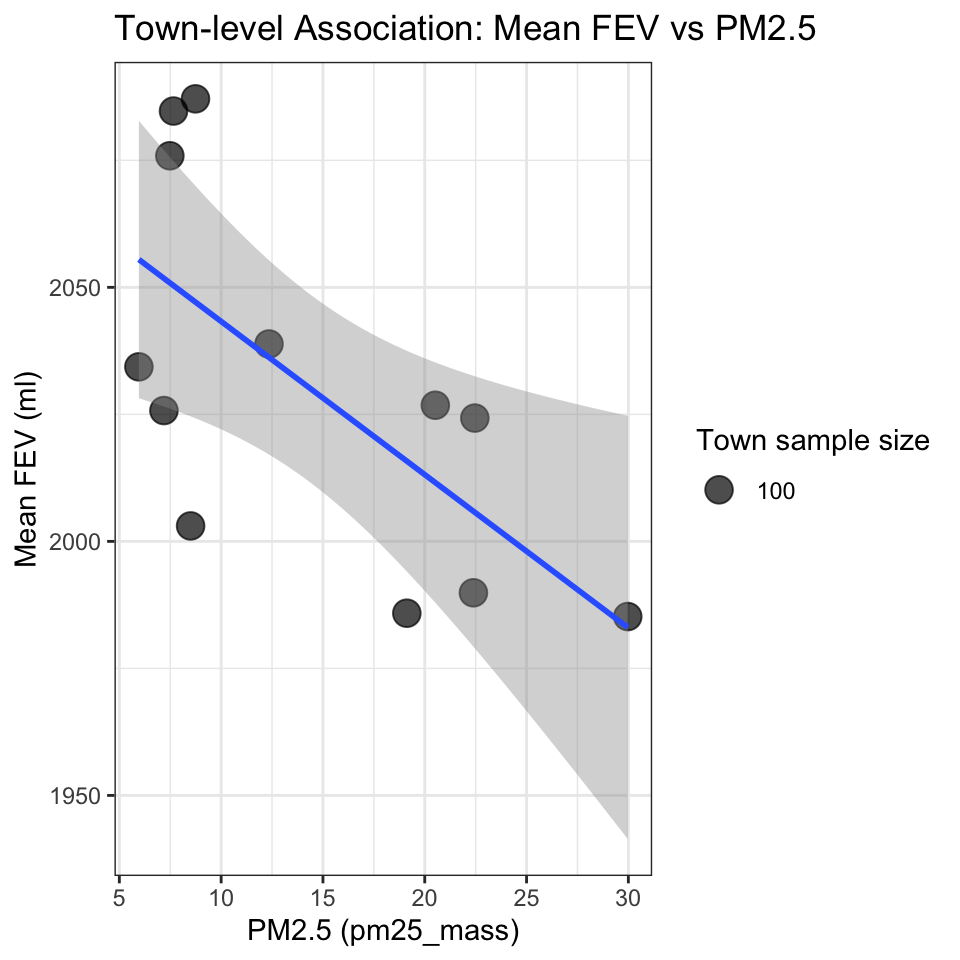

```r
## 6
town_assoc <- dat_imp %>%
  group_by(townname) %>%
  summarise(
    mean_fev = mean(fev, na.rm = TRUE),
    pm25 = mean(pm25_mass, na.rm = TRUE),
    n = n(),
    .groups = "drop"
  )

p6 <- ggplot(town_assoc, aes(x = pm25, y = mean_fev)) +
  geom_point(aes(size = n), alpha = 0.7) +
  geom_smooth(method = "lm", se = TRUE) +
  scale_size_continuous(name = "Town sample size") +
  labs(
    title = "Town-level Association: Mean FEV vs PM2.5",
    x = "PM2.5 (pm25_mass)",
    y = "Mean FEV (ml)"
  ) +
  theme_bw()

print(p6)
```

This town level plot suggests a negative association between PM2.5 and lung function. Towns with higher PM2.5 tend to have lower mean FEV. The fitted regression line slopes downward, while the shaded 95% confidence band indicates uncertainty due to the small number of towns. Because each point represents a town average, this figure primarily captures between town differences rather than individual level exposure effects.